# United States Covid Case Rates and Death Rates by State throughout the Pandemic

A. Kajuch

2024-10-14

# Purpose

The purpose of this report is to look at COVID-19 data in the United States from Johns Hopkins and take a more in depth view at the case rates and death rates from each state.

## Librarys

```r
library(tidyr)
```

```r
library(ggplot2)
library(dplyr)
library(maps)
library(lubridate)
library(viridis)
library(stringr)
library(readr)
library(lolcat)
```

## Loading in Data

```r
url_in <- "https://raw.githubusercontent.com/CSSEGISandData/COVID-19/"

file_names<- c("refs/heads/master/csse_covid_19_data/csse_covid_19_time_series/time_series_covid19_confirmed_US.csv",
               "refs/heads/master/csse_covid_19_data/csse_covid_19_time_series/time_series_covid19_deaths_US.csv",
               "refs/heads/master/csse_covid_19_data/csse_covid_19_time_series/time_series_covid19_recovered_global.csv")

urls <- str_c(url_in, file_names)

US_cases <- read_csv(urls[1])
US_deaths <- read_csv(urls[2])
global_recovered <- read_csv(urls[3])
```

## Tidy Data

While tidying the data we wanted to get rid of unwanted columns and narrow down what data we wanted to view.

```r
US_cases <- US_cases %>%
  pivot_longer(cols = -(UID:Combined_Key),
               names_to = "date",
               values_to = "cases") %>%
  select(Admin2:cases) %>%
  mutate(date = mdy(date)) %>%
  select(-c(Lat,Long_))

US_deaths <- US_deaths %>%
  pivot_longer(cols = -(UID:Combined_Key),
               names_to = "date",
               values_to = "deaths") %>%
  select(Admin2:deaths) %>%
  filter(!grepl("[^0-9/]", date)) %>%
  mutate(date = mdy(date)) %>%
  filter(!is.na(date)) %>%
  select(-c(Lat, Long_))


US <- US_cases %>%
  full_join(US_deaths, by = c("Admin2", "Province_State", "Country_Region", "Combined_Key", "date"))


US <- US %>% filter(cases > 0)
```

# Bring in Population data

Combining the states population data with the COVID-19 data, we are able to now create rates relative to the population of each state.

```r
uid_lookup_url <- "https://raw.githubusercontent.com/CSSEGISandData/COVID-19/refs/heads/master/csse_covid_19_data/UID_ISO_FIPS_LookUp_Table.csv"
uid <- read_csv(uid_lookup_url) %>%
  filter(is.na(Admin2)) %>%
  filter(Country_Region == "US") %>%
  select(-c(code3, iso2, iso3))
USjoined<- US%>%
  left_join(uid, by = c("Province_State", "Country_Region")) %>%
  select(-c(UID, FIPS)) %>%
  select(Province_State, Country_Region, date, cases, deaths, Population)
head(USjoined)
```

```
## # A tibble: 6 × 6
##   Province_State Country_Region date       cases deaths Population
##   <chr>          <chr>          <date>     <dbl>  <dbl>      <dbl>
## 1 Alabama        US             2020-03-24     1      0    4903185
## 2 Alabama        US             2020-03-25     5      0    4903185
## 3 Alabama        US             2020-03-26     6      0    4903185
## 4 Alabama        US             2020-03-27     6      0    4903185
## 5 Alabama        US             2020-03-28     6      0    4903185
## 6 Alabama        US             2020-03-29     6      0    4903185
```

# Organize Data Over Time

Organizing the data over time allows for us to view each state year by year

```r
#Create Monthly per Year
USjoined <- USjoined %>%
  mutate(year = year(date), month = month(date, label = TRUE))

# States Monthly Adjustment
Statesmonthly <- USjoined %>%
  group_by(Province_State, year, month, Population) %>%
  summarise(average_cases = mean(cases, na.rm = TRUE),
            total_cases = sum(cases, na.rm = TRUE),
            total_deaths = sum(deaths, na.rm = TRUE)) %>%
  ungroup()
Statesmonthly<- Statesmonthly %>%
  group_by(year, month) %>%
  mutate(case_rate = (average_cases /Population) * 100,
         death_rate = (total_deaths/total_cases) * 100) %>%
  ungroup()

head(Statesmonthly)
```

```
## # A tibble: 6 × 9
##   Province_State  year month Population average_cases total_cases total_deaths
##   <chr>          <dbl> <ord>      <dbl>         <dbl>       <dbl>        <dbl>
## 1 Alabama         2020 Mar      4903185          11.9        6735           45
## 2 Alabama         2020 Apr      4903185          64.1      127476         3996
## 3 Alabama         2020 May      4903185         182.       377501        14438
## 4 Alabama         2020 Jun      4903185         404.       812738        23430
## 5 Alabama         2020 Jul      4903185         934.      1938938        37405
## 6 Alabama         2020 Aug      4903185        1617.      3358162        56726
## # ℹ 2 more variables: case_rate <dbl>, death_rate <dbl>
```

```r
Statesyearly <- Statesmonthly %>%
  group_by(Province_State, year) %>%
  summarize(
    avg_case_rate = mean(case_rate, na.rm = TRUE),
    avg_death_rate = mean(death_rate, na.rm = TRUE)
  ) %>%
  ungroup()
head(Statesyearly)
```

```
## # A tibble: 6 × 4
##   Province_State  year avg_case_rate avg_death_rate
##   <chr>          <dbl>         <dbl>          <dbl>
## 1 Alabama         2020        0.0321          2.02
## 2 Alabama         2021        0.190           1.90
## 3 Alabama         2022        0.419           1.42
## 4 Alabama         2023        0.494           1.29
## 5 Alaska          2020        0.0451          0.930
## 6 Alaska          2021        0.415           0.516
```

# Load in US State Map

Loading in the data for the United States map, and combining it with the COVID-19 data.

```r
us_states_map <- map_data("state")

Statesyearly <- Statesyearly %>%
  mutate(Province_State = tolower(Province_State))

merged_case_rate <- us_states_map %>%
  left_join(Statesyearly, by = c("region" = "Province_State"))
merged_death_rate <- merged_case_rate
```

## Plot The Heat Map

```r
# Function to plot heat map for case rate
plot_case_rate_heatmap <- function(year) {
  ggplot(data = filter(merged_case_rate, year == !!year), aes(long, lat, group = group, fill = avg_case_rate)) +
    geom_polygon(color = "white") +
    scale_fill_gradient2(
      low = "green", mid = "yellow", high = "red", midpoint = .75, limits = c(0, 1.5),
      name = "Case Rate (%)", na.value = "red"
    ) +
    labs(title = paste("Average Case Rate in", year), x = "", y = "") +
    theme_minimal() +
    theme(axis.text = element_blank(),
          axis.ticks = element_blank(),
          panel.grid = element_blank()) +
    coord_fixed(1.3)
}

plot_death_rate_heatmap <- function(year) {
  ggplot(data = filter(merged_case_rate, year == !!year), aes(long, lat, group = group, fill = avg_death_rate)) +
    geom_polygon(color = "white") +
    scale_fill_gradient2(
      low = "green", mid = "yellow", high = "red", midpoint = 1.5, limits = c(0, 3),
      name = "Death Rate (%)", na.value = "red"
    ) +
    labs(title = paste("Average Death Rate in", year), x = "", y = "") +
    theme_minimal() +
    theme(axis.text = element_blank(),
          axis.ticks = element_blank(),
          panel.grid = element_blank()) +
    coord_fixed(1.3)
}
```

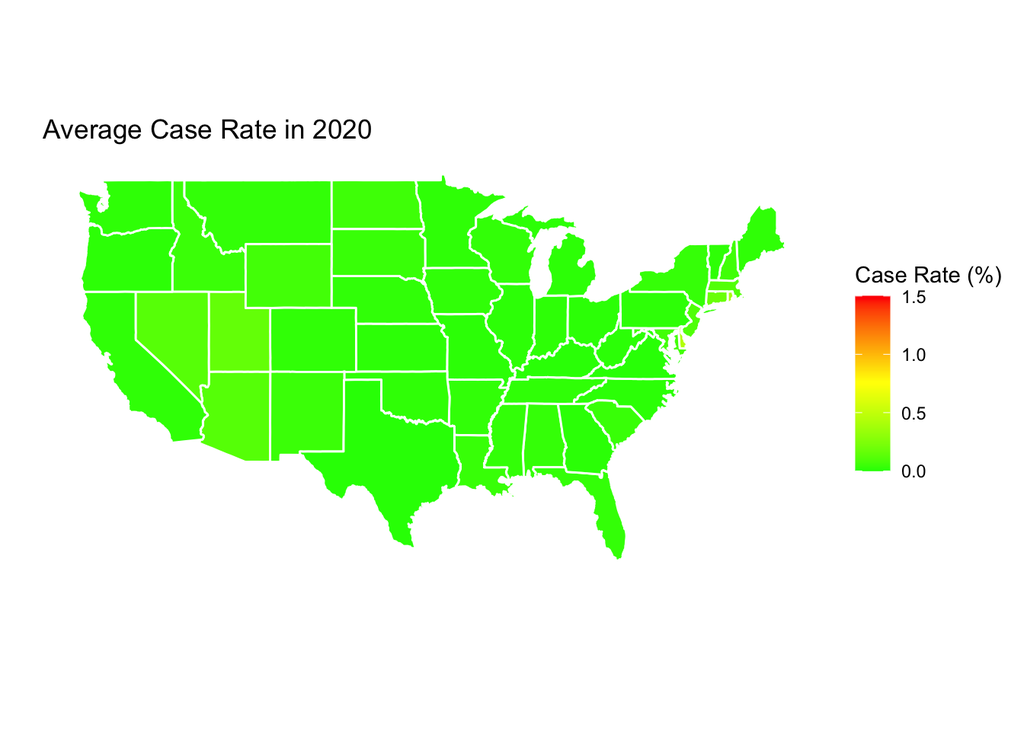

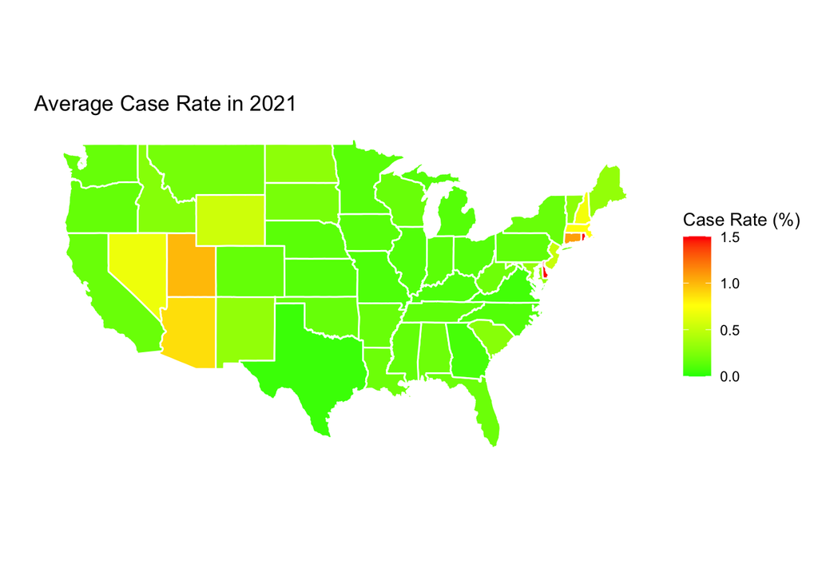

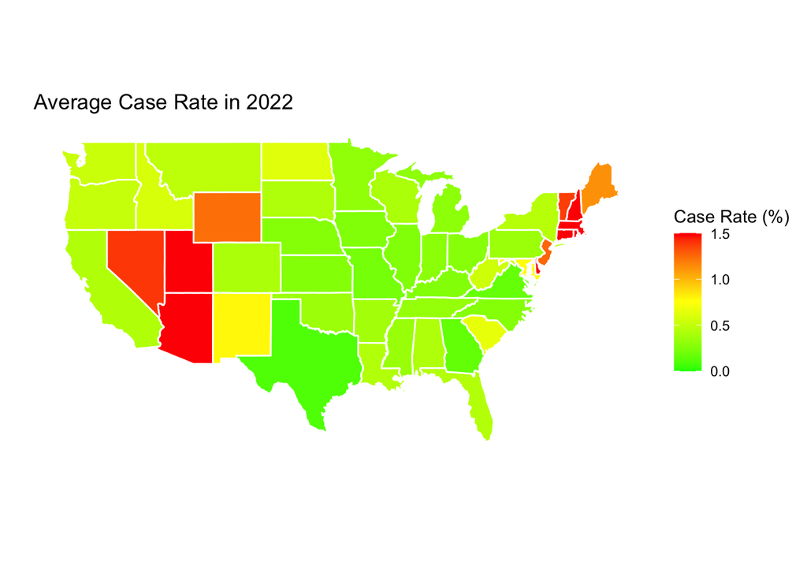

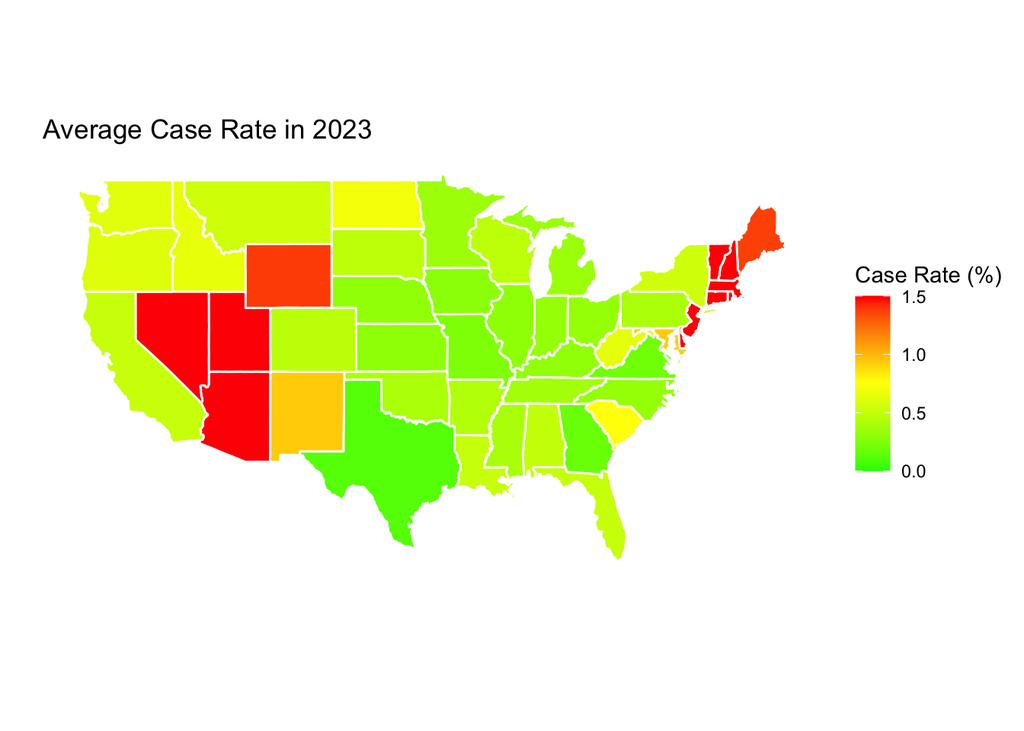

```r
for (year in 2020:2023) {
  print(plot_case_rate_heatmap(year))
}
```